# Stat 480 - Homework #2

Zahra Khoshmansh

1/27/2020

## Economic Guide to Picking a College Major

1. Download the RMarkdown file with these homework instructions to use as a template for your work. Make sure to replace “Your Name” in the YAML with your name.
2. Using the command below, read in the data set into your R session.

```r
recent_grads <- read.csv("https://raw.githubusercontent.com/Stat480-at-ISU/materials-2020/master/02-r_intro/data/recent_grads.csv")
```

3. Create a new variable, `share_women`, that is women as share of total; i.e. the number of women divided by the total number of men and women.
4. Create a subset of the data containing only the rows where the `major_category` is `STEM`.
5. For your subset, compute the average of `share_women` and its standard deviation. Also compute the average median earnings (`median`) and its standard deviation. Comment on the results. (You might have to deal with missing values appropriately).
6. Compute the correlation between women as a share of total (`share_women`) and the median earnings (`median`) and interpret your results.
7. Use the original dataset and `ggplot2` to draw a scatterplot of women as share of total and the median earnings. Color points by the major category (`major_category`). Comment on the result.

Due date: the homework is due before class on Thursday.

For the submission: submit your solution in an R Markdown file and (just for insurance) submit the corresponding html file with it.

## Solution

```r
#2-read dataset
recent_grads <- read.csv("https://raw.githubusercontent.com/Stat480-at-ISU/materials-2020/master/02-r_intro/data/recent_grads.csv")
```

```r
#3-Create a new variable, `share_women`, that is women as share of total; i.e. the number of women divided by the total number of men and women.
recent_grads$share_women <- recent_grads$Women/(recent_grads$Women + recent_grads$Men)
head(recent_grads)
```

```
##                                       Major Major_category Unemployment_rate
## 1                     PETROLEUM ENGINEERING           STEM        0.01838053
## 2            MINING AND MINERAL ENGINEERING           STEM        0.11724138
## 3                 METALLURGICAL ENGINEERING           STEM        0.02409639
## 4 NAVAL ARCHITECTURE AND MARINE ENGINEERING           STEM        0.05012531
## 5                      CHEMICAL ENGINEERING           STEM        0.06109771
## 6                       NUCLEAR ENGINEERING           STEM        0.17722641
##   Median Women   Men share_women
## 1 110000   282  2057   0.1205643
## 2  75000    77   679   0.1018519
## 3  73000   131   725   0.1530374
## 4  70000   135  1123   0.1073132
## 5  65000 11021 21239   0.3416305
## 6  65000   373  2200   0.1449670
```

```r
#4-Create a subset of the data containing only the rows where the `major_category` is `STEM`
STEM <- recent_grads %>% filter(Major_category %in% "STEM")
head(STEM)
```

```
##                                       Major Major_category Unemployment_rate
## 1                     PETROLEUM ENGINEERING           STEM        0.01838053
## 2            MINING AND MINERAL ENGINEERING           STEM        0.11724138
## 3                 METALLURGICAL ENGINEERING           STEM        0.02409639
## 4 NAVAL ARCHITECTURE AND MARINE ENGINEERING           STEM        0.05012531
## 5                      CHEMICAL ENGINEERING           STEM        0.06109771
## 6                       NUCLEAR ENGINEERING           STEM        0.17722641
##   Median Women   Men share_women
## 1 110000   282  2057   0.1205643
## 2  75000    77   679   0.1018519
## 3  73000   131   725   0.1530374
## 4  70000   135  1123   0.1073132
## 5  65000 11021 21239   0.3416305
## 6  65000   373  2200   0.1449670
```

```r
#5-For your subset, compute the average  of `share_women` and its standard deviation. Also compute the average median earnings (`median`) and its standard deviation. Comment on the results. (You might have to deal with missing values appropriately).
mean_share_woman <- mean(recent_grads$share_women,na.rm = TRUE)
mean_share_woman
```

```
## [1] 0.5222234
```

```r
sd_share_woman <- sd(recent_grads$share_women,na.rm = TRUE)
sd_share_woman
```

```
## [1] 0.231205
```

```r
mean_median_earnings <- mean(recent_grads$Median,na.rm = TRUE)
mean_median_earnings
```

```
## [1] 40151.45
```

```r
sd_median_earnings <- sd(recent_grads$Median,na.rm = TRUE)
sd_median_earnings
```

```
## [1] 11470.18
```

```r
#6- Compute the correlation between women as a share of total (`share_women`) and the median earnings (`median`) and interpret your results.

correlation <- cor.test(recent_grads$share_women,recent_grads$Median, method = "pearson")
correlation
```

```
##
##  Pearson's product-moment correlation
##
## data:  recent_grads$share_women and recent_grads$Median
## t = -10.268, df = 170, p-value < 2.2e-16
## alternative hypothesis: true correlation is not equal to 0
## 95 percent confidence interval:
##  -0.7032218 -0.5169094
## sample estimates:
##        cor
## -0.6186898
```

correlation is -0.6186898 which indicates variables which can be considered moderately correlated.

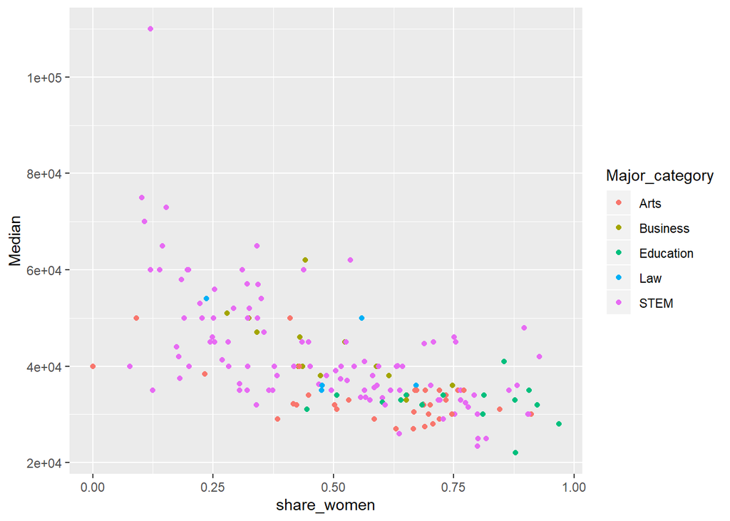

```r
#7- Use the original dataset and `ggplot2` to draw a scatterplot of women as share of total and the median earnings. Color points by the major category (`major_category`). Comment on the result.
ggplot(data= recent_grads,aes(x=share_women,y=Median))+
  geom_point(aes(color=Major_category))
```

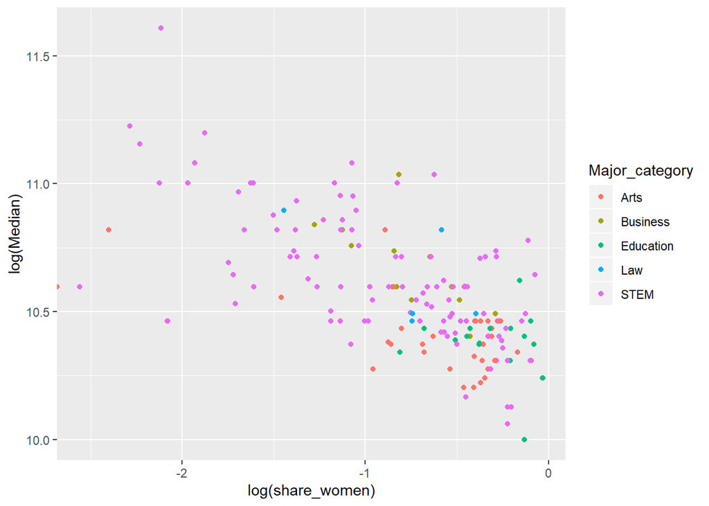

```r
ggplot(data = recent_grads, aes(x = log(share_women), y = log(Median))) +
  geom_point(aes(color=Major_category))
```

Interpretation of result:

1. Form: Linear
2. Strength: not strong. Data points are scattered.
3. Direction: Negatively Associated.
4. an outlier. look at below code

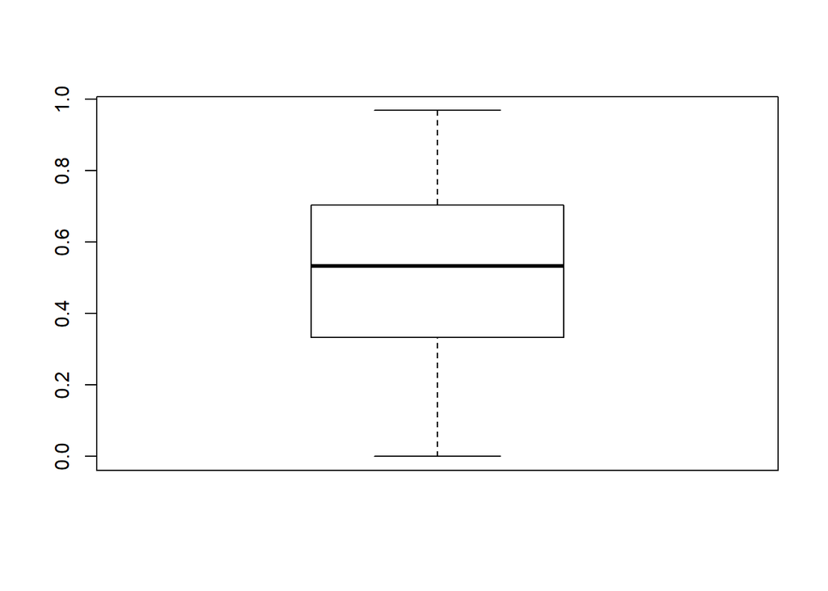

```r
#check for outlier in indivisual variables
boxplot(recent_grads$share_women)
```

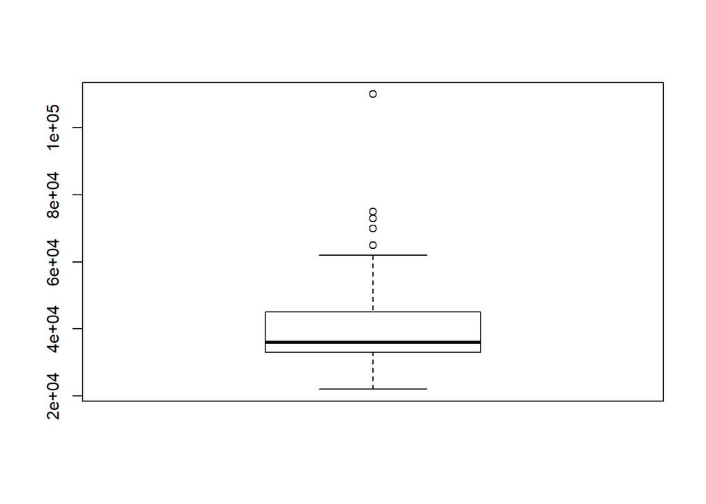

```r
boxplot(recent_grads$Median)#median has some outliers
```

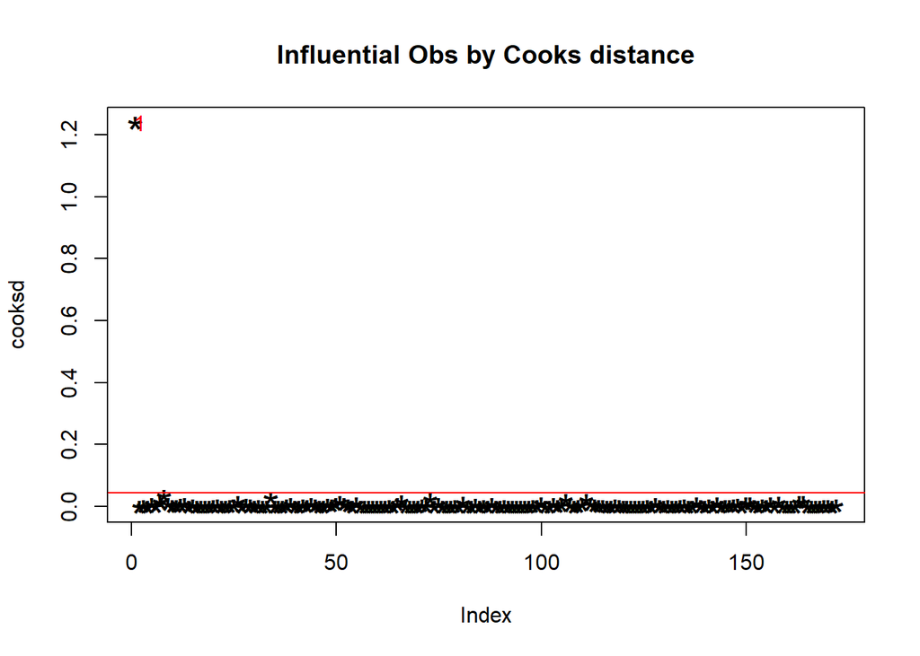

```r
# use cook distance to check the outlier
mod <- lm(share_women ~ recent_grads$Median, data=recent_grads)
cooksd <- cooks.distance(mod)

plot(cooksd, pch="*", cex=2, main="Influential Obs by Cooks distance")  # plot cook's distance
abline(h = 4*mean(cooksd, na.rm=T), col="red")  # add cutoff line
text(x=1:length(cooksd)+1, y=cooksd, labels=ifelse(cooksd>4*mean(cooksd, na.rm=T),names(cooksd),""), col="red")  # add labels
```